# Analyse der Matoma-HaNS-Daten

Author

Sebastian Sauer

Published

July 25, 2025

# 1 Hintergrund

Dieser Arbeitsbericht schildert das technische Vorgehen im Rahmen der Analyse der Matomo-Daten des BMBF-Projekt “HaNS”.

## 1.1 Vorgehen

Die Matomo-Klickdaten aller Semester der Projektlaufzeit wurden für diese Analyse verarbeitet. Mit Hilfe einer R-Pipeline wurden eine Reihe von Forschungsfragen analysiert.

Der komplette Code ist online dokumentiert unter https://github.com/sebastiansauer/hans. Aus Datenschutzgründen sind online keine Daten eingestellt.

Die zentrale Analyse-Pipeline-Datei ist https://github.com/sebastiansauer/hans/blob/main/_targets.R.

## 1.2 Forschungsfragen

1. Wie viele Nutzer gibt es und in welchem Zeitraum?
2. In welcher Frequenz wird HaNS aufgesucht? Wie groß sind die zeitlichen Zwischenräume zwischen der Benutzung der Plattform?
3. Wie oft wird HaNS pro Zeitraum (z.B. Monat) besucht?
4. Wie verändert sich die Nutzung im Zeitverlauf?
5. Wie viele Aktionen bringt ein Visit mit sich? Wie ist die statistische Verteilung der Aktionen pro Visit?
6. Wie lang verweilen die Nutzer pro Visit?
7. Wie verändert sich die Nutzungsdauer pro Visit im Zeitverlauf?
8. Welche Aktionen führen die Nutzer auf Hans aus?
9. Wie verändern sich die Verteilungen der Aktionshäufigkeiten im Zeitverlauf?
10. An welchen Tagen und zu welcher Zeit kommen die User zu HaNS?
11. Wie häufig und in welcher Art inteagieren die Nutzer mit dem LLM in HaNS?
12. Wie groß ist der Anteil der Nutzer, die mit dem LLM interagieren?
13. Wie verändert sich der Anteil der Nutzer, die mit dem LLM interagieren, im Zeitverlauf?
14. Wie oft wird auf ein Wort im Transkript des LLM geklickt?
15. Wie oft wird ein Transkript-Dienst in HaNS in Anspruch genommen?
16. Wie verändert sich die Nutzung der Transkript-Dienste in HaNS im Zeitverlauf?
17. Wie lange werden Videos angeschaut?
18. Wie verändert sich die Betrachtungsdauer im Zeitverlauf?

# 2 Setup

## 2.1 R-Pakete starten

```r
library(targets)
library(tidyverse)
library(ggokabeito)
library(easystats)
library(gt)
library(ggfittext)
library(scales)
library(visdat)
library(collapse)
library(ggpubr)
library(knitr)
library(tinytable)
```

```r
library(ggplot2)
theme_set(theme_minimal())
```

## 2.2 Optionen setzen

```r
options(lubridate.week.start = 1)  # Monday as first day
#options(collapse_mask = "all") # use collapse for all dplyr operations
options(chromote.headless = "new")  # Chrome headleass needed for gtsave
```

```r
scale_colour_discrete <- function(...) scale_colour_brewer(palette = "Set2")
scale_fill_discrete <- function(...) scale_fill_brewer(palette = "Set2")
```

# 3 Datenaufbereitung und Analysepipeline

## 3.1 Targets-Pipeline stellt Überblick aller Analyseschritte dar

Die Analyse wird im Rahmen einer [Targets-Pipeline](https://github.com/sebastiansauer/hans/blob/main/_targets.R) beschrieben und ist offen auf Github einsehbar.

## 3.2 Langformat

Aufgrund des “rechts flatternden” Datenformat (d.h. unterschiedliche Zeilenlängen) wurden die Daten in ein Langformat überführt, zwecks besserer/einfacherer Analyse.

Dazu wurden (neben den ID-Variablen, v.a. `idvisit`) die `actionDetails_`-Variablen verwendet. Der Code des Pivotierens in das Langformat ist in der Funktion longify-data.R einsehbar.

Die Daten im Langformat wurden dann noch etwas aufbereitet mt der Funktion [slimify-data.R](https://github.com/sebastiansauer/hans/blob/main/funs/slimify_data.R).

```r
tar_load(data_slim_filtered_head)

data_slim_filtered_head |>
  head(30)
```

|  | nr | type | value | idvisit |
| --- | --- | --- | --- | --- |
| 1 | 0 | subtitle | https://hans.th-nuernberg.de/ | 1 |
| 2 | 0 | timestamp | 2023-03-23 18:37:56 | 1 |
| 3 | 1 | eventcategory | click_button | 1 |
| 4 | 1 | eventaction | Medien | 1 |
| 5 | 1 | timestamp | 2023-03-23 18:37:56 | 1 |
| 6 | 1 | subtitle | Category: ""click_button', Action: ""Medien"" | 1 |
| 7 | 2 | subtitle | https://hans.th-nuernberg.de/channels | 1 |
| 8 | 2 | timestamp | 2023-03-23 18:37:59 | 1 |
| 9 | 3 | eventcategory | click_button | 1 |
| 10 | 3 | eventaction | Kanäle | 1 |

[output cut: 20 more lines]

# 4 Überblick über die Daten

## 4.1 Roh-Daten laden und inspizieren (data_all_fact)

```r
tar_load(data_all_fct)
```

### 4.1.1 Dimension

Der Roh-Datensatz verfügt über

Jede Zeile entspricht einem “Visit”.

### 4.1.2 Erster Blick

```r
data_all_fct_head100 <-
data_all_fct %>%
  select(1:100) %>%
  slice_head(n = 100)
```

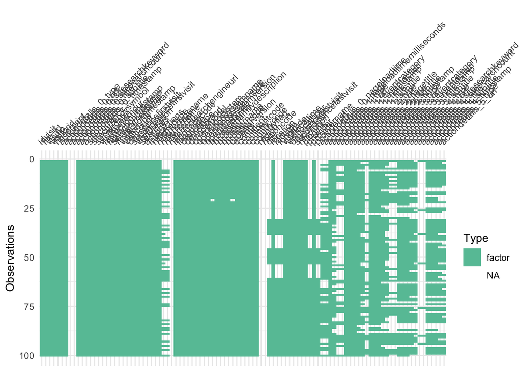

```r
data_all_fct_head100 %>%
  visdat::vis_dat()
```

### 4.1.3 (Fast) leere Spalten

```r
d_na_cols <- data.frame(
  id = 1:ncol(data_all_fct),
  names = names(data_all_fct),
  na_prop = colMeans(is.na(data_all_fct)))
```

#### 4.1.3.1 Leere Spalten

```r
d_na_cols |>
  filter(na_prop == 1)
```

|  | id | names | na_prop |
| --- | --- | --- | --- |
| actiondetails_0_sitesearchkeyword | 8 | actiondetails_0_sitesearchkeyword | 1 |
| actiondetails_0_sitesearchcount | 9 | actiondetails_0_sitesearchcount | 1 |
| actiondetails_363_pageloadtime | 4261 | actiondetails_363_pageloadtime | 1 |
| actiondetails_363_pageloadtimemilliseconds | 4262 | actiondetails_363_pageloadtimemilliseconds | 1 |
| actiondetails_257_sitesearchkeyword | 4271 | actiondetails_257_sitesearchkeyword | 1 |
| actiondetails_257_sitesearchcount | 4272 | actiondetails_257_sitesearchcount | 1 |
| actiondetails_193_sitesearchkeyword | 4333 | actiondetails_193_sitesearchkeyword | 1 |
| actiondetails_193_sitesearchcount | 4334 | actiondetails_193_sitesearchcount | 1 |
| actiondetails_322_sitesearchkeyword | 4343 | actiondetails_322_sitesearchkeyword | 1 |
| actiondetails_322_sitesearchcount | 4344 | actiondetails_322_sitesearchcount | 1 |

[output cut: 27 more lines]

#### 4.1.3.2 Fast leere Spalten

```r
d_na_cols |>
  filter(na_prop > .9) |>
  nrow()
```

```
[1] 3322
```

Sehr viele Spalten sind fast leer.

### 4.1.4 Namen (1-100)

```r
d_100_names <- data.frame(
  id = 1:100,
  col_name = data_all_fct_head100 %>% names())

d_100_names
```

| id | col_name |
| --- | --- |
| 1 | idvisit |
| 2 | file_id |
| 3 | visitip |
| 4 | visitorid |
| 5 | fingerprint |
| 6 | actiondetails_0_type |
| 7 | actiondetails_0_url |
| 8 | actiondetails_0_sitesearchkeyword |
| 9 | actiondetails_0_sitesearchcount |
| 10 | actiondetails_0_title |

[output cut: 90 more lines]

### 4.1.5 Werte der erst 100 Spalten

```r
data_all_fct_head100
```

| idvisit | file_id | visitip | visitorid | fingerprint | actiondetails_0_type | actiondetails_0_url | actiondetails_0_sitesearchkeyword | actiondetails_0_sitesearchcount | actiondetails_0_title | actiondetails_0_subtitle | actiondetails_0_timestamp | sitecurrency | sitecurrencysymbol | serverdate | visitserverhour | lastactiontimestamp | lastactiondatetime | servertimestamp | firstactiontimestamp | visitortype | visitcount | dayssincefirstvisit | secondssincefirstvisit | visitduration | searches | actions | interactions | referrertype | referrertypename | … |
| --- | --- | --- | --- | --- | --- | --- | --- | --- | --- | --- | --- | --- | --- | --- | --- | --- | --- | --- | --- | --- | --- | --- | --- | --- | --- | --- | --- | --- | --- | --- |
| 1 | matomo_export_2023-03-23.csv | 217.85.0.0 | 222edbe56ec28397 | aa8a78771b4f21ff | action | https://hans.th-nuernberg.de/ | NA | NA | HAnS | https://hans.th-nuernberg.de/ | 2023-03-23 18:37:56 | USD | $ | 2023-03-23 | 18 | 2023-03-23 18:02:49 | 2023-03-23 18:02:49 | 2023-03-23 18:02:49 | 2023-03-23 17:37:56 | returning | 4 | 0 | 15464 | 1494 | 7 | 158 | 38 | direct | Direct Entry | … |
| 2 | matomo_export_2023-03-23.csv | 217.85.0.0 | 222edbe56ec28397 | aa8a78771b4f21ff | action | https://hans.th-nuernberg.de/channels | NA | NA | HAnS | https://hans.th-nuernberg.de/channels | 2023-03-23 17:18:10 | USD | $ | 2023-03-23 | 17 | 2023-03-23 17:00:44 | 2023-03-23 17:00:44 | 2023-03-23 17:00:44 | 2023-03-23 16:18:10 | returning | 3 | 0 | 10678 | 2555 | 2 | 12 | 7 | direct | Direct Entry | … |
| 3 | matomo_export_2023-03-23.csv | 141.75.0.0 | 1ddd5dfacfa787a4 | 1f026ad3cbbdf325 | action | https://hans.th-nuernberg.de/ | NA | NA | HAnS | https://hans.th-nuernberg.de/ | 2023-03-23 17:17:36 | USD | $ | 2023-03-23 | 16 | 2023-03-23 16:18:54 | 2023-03-23 16:18:54 | 2023-03-23 16:18:54 | 2023-03-23 16:17:36 | new | 1 | 0 | 0 | 79 | 1 | 9 | 5 | direct | Direct Entry | … |
| 4 | matomo_export_2023-03-23.csv | 217.85.0.0 | 222edbe56ec28397 | aa8a78771b4f21ff | event | https://hans.th-nuernberg.de/ | NA | NA | Event | Category: ""click_button', Action: ""Kanäle"" | 2023-03-23 15:15:59 | USD | $ | 2023-03-23 | 15 | 2023-03-23 15:47:17 | 2023-03-23 15:47:17 | 2023-03-23 15:47:17 | 2023-03-23 14:15:59 | returning | 2 | 0 | 3347 | 5479 | 9 | 108 | 52 | direct | Direct Entry | … |
| 5 | matomo_export_2023-03-23.csv | 217.85.0.0 | 74773ced8f01a582 | aa8a78771b4f21ff | action | https://hans.th-nuernberg.de/login | NA | NA | HAnS | https://hans.th-nuernberg.de/login | 2023-03-23 14:20:12 | USD | $ | 2023-03-23 | 13 | 2023-03-23 13:37:45 | 2023-03-23 13:37:45 | 2023-03-23 13:37:45 | 2023-03-23 13:20:12 | new | 1 | 0 | 0 | 1054 | 0 | 25 | 13 | direct | Direct Entry | … |
| 6 | matomo_export_2023-03-23.csv | 31.16.0.0 | d7efc2b1d308e9d6 | 518965d4e1ae7e2d | action | https://hans.th-nuernberg.de/login | NA | NA | HAnS | https://hans.th-nuernberg.de/login | 2023-03-23 14:29:42 | USD | $ | 2023-03-23 | 13 | 2023-03-23 13:31:36 | 2023-03-23 13:31:36 | 2023-03-23 13:31:36 | 2023-03-23 13:29:42 | new | 1 | 0 | 0 | 115 | 0 | 2 | 2 | website | Websites | … |
| 7 | matomo_export_2023-03-24.csv | 217.84.0.0 | c77ae8b840d8aba9 | aa957061ec277742 | event | https://hans.th-nuernberg.de/video-player?uuid=d7d95ab4-ffdf-4465-9823-38289f147b74 | NA | NA | Event | Category: ""videoplayer_click', Action: ""play"" | 2023-03-24 17:58:33 | USD | $ | 2023-03-24 | 17 | 2023-03-24 17:33:17 | 2023-03-24 17:33:17 | 2023-03-24 17:33:17 | 2023-03-24 16:58:33 | returning | 5 | 0 | 75423 | 2085 | 0 | 13 | 0 | website | Websites | … |
| 8 | matomo_export_2023-03-24.csv | 141.75.0.0 | 1564fdddf996ae28 | e89126eaae40660e | event | https://hans.th-nuernberg.de/video-player?uuid=c79209da-d1b7-4048-9623-133d5def7d94 | NA | NA | Event | Category: ""click_button', Action: ""Kanäle"" | 2023-03-24 16:06:55 | USD | $ | 2023-03-24 | 15 | 2023-03-24 15:33:48 | 2023-03-24 15:33:48 | 2023-03-24 15:33:48 | 2023-03-24 15:06:55 | returning | 2 | 0 | 22139 | 1614 | 1 | 11 | 3 | direct | Direct Entry | … |
| 9 | matomo_export_2023-03-24.csv | 217.84.0.0 | c77ae8b840d8aba9 | aa957061ec277742 | event | https://hans.th-nuernberg.de/video-player?uuid=d7d95ab4-ffdf-4465-9823-38289f147b74 | NA | NA | Event | Category: ""videoplayer_click', Action: ""play"" | 2023-03-24 16:21:10 | USD | $ | 2023-03-24 | 15 | 2023-03-24 15:26:44 | 2023-03-24 15:26:44 | 2023-03-24 15:26:44 | 2023-03-24 15:21:10 | returning | 4 | 0 | 69580 | 335 | 0 | 7 | 0 | website | Websites | … |
| 10 | matomo_export_2023-03-24.csv | 141.75.0.0 | 222edbe56ec28397 | 14e1d60a5ac559aa | action | https://hans.th-nuernberg.de/channels | NA | NA | HAnS | https://hans.th-nuernberg.de/channels | 2023-03-24 15:30:36 | USD | $ | 2023-03-24 | 15 | 2023-03-24 15:20:47 | 2023-03-24 15:20:47 | 2023-03-24 15:20:47 | 2023-03-24 14:30:36 | returning | 8 | 1 | 90624 | 3012 | 12 | 61 | 31 | direct | Direct Entry | … |

[output cut: 90 more lines]

### 4.1.6 Datensatz data_slim_filtered, Zeilen 1-100

```r
tar_load(data_slim_filtered)

data_slim_filtered %>%
  slice(1:100)
```

| nr | type | value | idvisit |
| --- | --- | --- | --- |
| 0 | subtitle | https://hans.th-nuernberg.de/ | 1 |
| 0 | timestamp | 2023-03-23 18:37:56 | 1 |
| 1 | eventcategory | click_button | 1 |
| 1 | eventaction | Medien | 1 |
| 1 | timestamp | 2023-03-23 18:37:56 | 1 |
| 1 | subtitle | Category: ""click_button', Action: ""Medien"" | 1 |
| 2 | subtitle | https://hans.th-nuernberg.de/channels | 1 |
| 2 | timestamp | 2023-03-23 18:37:59 | 1 |
| 3 | eventcategory | click_button | 1 |
| 3 | eventaction | Kanäle | 1 |

[output cut: 90 more lines]

## 4.2 Fallzahl im Nur-User-Datensatz

Entfernt man *Developer*, *Admins* und *Lecturers* aus dem Roh-Datensatz so bleiben weniger Zeilen übrig:

```r
tar_load(data_users_only)
```

- 11383 Zeilen
- 8399 Spalten

## 4.3 Datensatz mit Anzahl der Aktionen pro User

```r
tar_load(n_action)

n_action |>
  head(30)
```

| idvisit | nr_max |
| --- | --- |
| 1 | 157 |
| 2 | 11 |
| 3 | 8 |
| 4 | 107 |
| 5 | 24 |
| 6 | 1 |
| 7 | 12 |
| 8 | 10 |
| 9 | 6 |
| 10 | 60 |

[output cut: 20 more lines]

# 5 Zeitraum

## 5.1 Beginn/Ende der Daten

```r
tar_load(config)
```

```r
tar_load(n_action_w_date)

n_action_w_date |>
  head(30)
```

| idvisit | nr_max | date_time_start | month_of_visit | month_date | week_date | week_of_visit | year_of_visit | hour_of_visit_start |
| --- | --- | --- | --- | --- | --- | --- | --- | --- |
| 1 | 157 | 2023-03-23 18:37:56 | Mar | 2023-03-01 | 2023-03-20 | 12 | 2023 | 18 |
| 2 | 11 | 2023-03-23 17:18:10 | Mar | 2023-03-01 | 2023-03-20 | 12 | 2023 | 17 |
| 3 | 8 | 2023-03-23 17:17:36 | Mar | 2023-03-01 | 2023-03-20 | 12 | 2023 | 17 |
| 4 | 107 | 2023-03-23 15:15:59 | Mar | 2023-03-01 | 2023-03-20 | 12 | 2023 | 15 |
| 5 | 24 | 2023-03-23 14:20:12 | Mar | 2023-03-01 | 2023-03-20 | 12 | 2023 | 14 |
| 6 | 1 | 2023-03-23 14:29:42 | Mar | 2023-03-01 | 2023-03-20 | 12 | 2023 | 14 |
| 7 | 12 | 2023-03-24 17:58:33 | Mar | 2023-03-01 | 2023-03-20 | 12 | 2023 | 17 |
| 8 | 10 | 2023-03-24 16:06:55 | Mar | 2023-03-01 | 2023-03-20 | 12 | 2023 | 16 |
| 9 | 6 | 2023-03-24 16:21:10 | Mar | 2023-03-01 | 2023-03-20 | 12 | 2023 | 16 |
| 10 | 60 | 2023-03-24 15:30:36 | Mar | 2023-03-01 | 2023-03-20 | 12 | 2023 | 15 |

[output cut: 20 more lines]

```r
n_action_w_date |>
  summarise(time_min = min(date_time_start, na.rm = T),
            time_max = max(date_time_start, na.rm = T)) |>
  gt()
```

| time_min | time_max |
| --- | --- |
| 2022-12-05 15:33:45 | 2025-07-14 23:40:45 |

Diese Statistik wurde auf Basis des Datenobjekts `data_slim_filtered` berechnet, vgl. [das Target dieses Objekts in der Pipeline](https://github.com/sebastiansauer/hans/blob/main/_targets.R#L170).

## 5.2 Days since last visit

```r
tar_load(time_visit_wday)
tar_load(time_since_last_visit)
```

### 5.2.1 Insgesamt

```r
time_visit_wday |>
  head(30)
```

| idvisit | dow | hour | date_time |
| --- | --- | --- | --- |
| 1 | 4 | 18 | 2023-03-23 18:37:56 |
| 2 | 4 | 17 | 2023-03-23 17:18:10 |
| 3 | 4 | 17 | 2023-03-23 17:17:36 |
| 4 | 4 | 15 | 2023-03-23 15:15:59 |
| 5 | 4 | 14 | 2023-03-23 14:20:12 |
| 6 | 4 | 14 | 2023-03-23 14:29:42 |
| 7 | 5 | 17 | 2023-03-24 17:58:33 |
| 8 | 5 | 16 | 2023-03-24 16:06:55 |
| 9 | 5 | 16 | 2023-03-24 16:21:10 |
| 10 | 5 | 15 | 2023-03-24 15:30:36 |

[output cut: 20 more lines]

```r
time_since_last_visit <-
time_since_last_visit |>
  mutate(dayssincelastvisit = as.numeric(dayssincelastvisit))

time_since_last_visit |>
  datawizard::describe_distribution(dayssincelastvisit) |>
  knitr::kable(digits = 2)
```

| Variable | Mean | SD | IQR | Min | Max | Skewness | Kurtosis | n | n_Missing |
| --- | --- | --- | --- | --- | --- | --- | --- | --- | --- |
| dayssincelastvisit | 2.17 | 7.92 | 0 | 0 | 128 | 6.71 | 60.54 | 14207 | 0 |

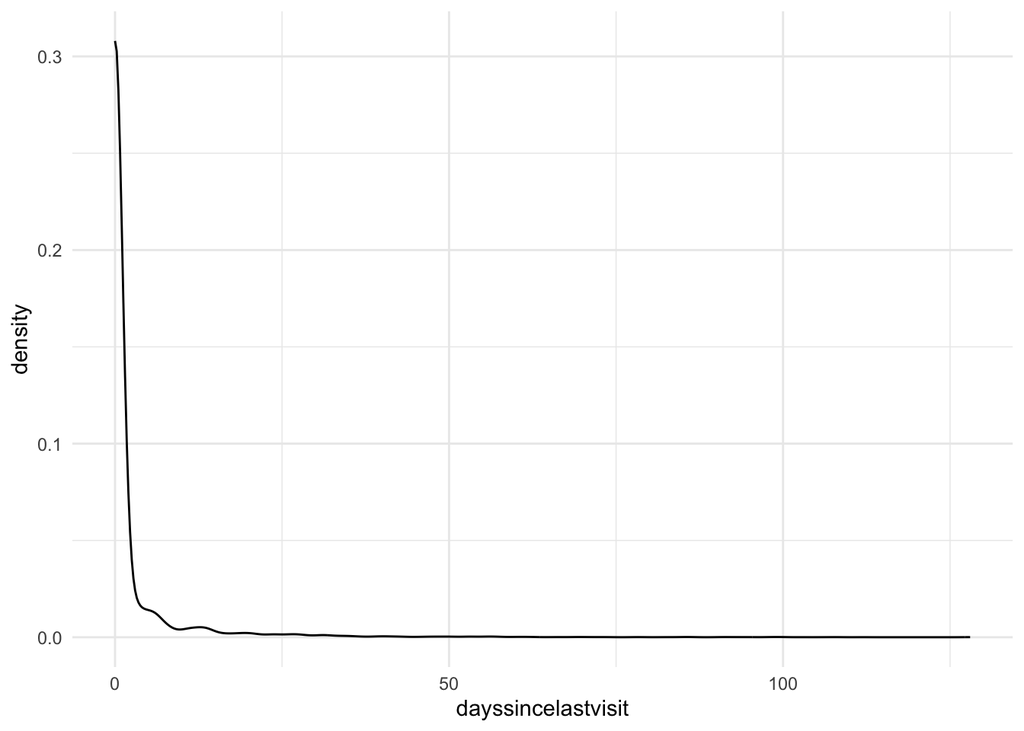

```r
time_since_last_visit |>
  ggplot(aes(x=dayssincelastvisit)) +
  geom_density()
```

### 5.2.2 Nach Lehrveranstaltungen

```r
tar_load(course_and_uni_per_visit)
```

```r
time_since_last_visit_per_course <-
time_since_last_visit |>
  left_join(course_and_uni_per_visit) |>
  drop_na()
```

```r
time_since_last_visit_per_course_summary <-
time_since_last_visit_per_course |>
  group_by(course) |>
  summarise(dayssincelastvisit_mean = mean(dayssincelastvisit),
            dayssincelastvisit_sd = sd(dayssincelastvisit),
            dayssincelastvisit_n = n()) |>
  mutate(dayssincelastvisit_n_log = log(dayssincelastvisit_n, base = 10) + 0.001)
```

```r
time_since_last_visit_per_course_summary |>
  print_md()
```

| course | dayssincelastvisit_mean | dayssincelastvisit_sd | dayssincelastvisit_n | dayssincelastvisit_n_log |
| --- | --- | --- | --- | --- |
| anis2 | 2.72 | 6.37 | 43 | 1.63 |
| armeufa | 0.00 | 0.00 | 2 | 0.30 |
| bare | 11.08 | 16.31 | 13 | 1.11 |
| bio | 1.85 | 6.43 | 168 | 2.23 |
| biotech | 2.02 | 8.45 | 127 | 2.10 |
| biovete | 1.24 | 4.41 | 244 | 2.39 |
| cta1 | 2.03 | 5.81 | 1109 | 3.05 |
| daba | 3.31 | 7.10 | 198 | 2.30 |
| enerbi | 3.90 | 6.95 | 10 | 1.00 |
| epsy | 16.00 |  | 1 | 1.00e-03 |
| etechde | 2.67 | 4.62 | 3 | 0.48 |
| fodesoa | 2.11 | 8.22 | 325 | 2.51 |
| fomesoa | 0.00 | 0.00 | 6 | 0.78 |
| fosaq | 7.57 | 17.36 | 60 | 1.78 |
| gdi | 7.75 | 20.32 | 48 | 1.68 |
| gemwesa | 0.77 | 3.20 | 57 | 1.76 |
| gesoa | 2.61 | 8.12 | 2335 | 3.37 |
| kore | 3.00 | 5.20 | 3 | 0.48 |
| mibio | 1.46 | 6.43 | 206 | 2.31 |
| mioek | 0.90 | 3.05 | 437 | 2.64 |
| nlp | 5.43 | 13.46 | 67 | 1.83 |
| quame1 | 0.00 | 0.00 | 3 | 0.48 |
| quanch | 1.85 | 5.92 | 34 | 1.53 |
| softa | 1.50 | 1.73 | 4 | 0.60 |
| thesoa | 4.45 | 10.81 | 283 | 2.45 |
| wirkori | 1.00 | 1.73 | 5 | 0.70 |
| wisoa | 0.36 | 1.14 | 33 | 1.52 |
| zemiws | 0.00 |  | 1 | 1.00e-03 |

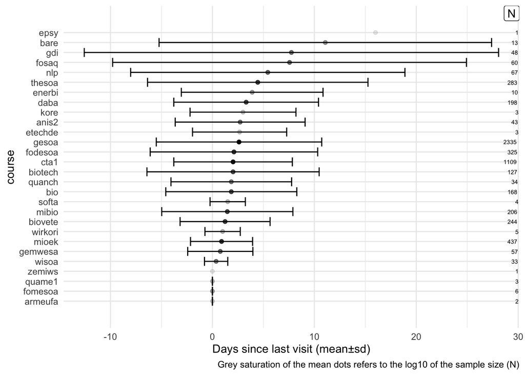

```r
time_since_last_visit_per_course_summary |>
  ggplot(aes(y = reorder(course, dayssincelastvisit_mean),
             x = dayssincelastvisit_mean)) +
  geom_errorbar(aes(xmin = dayssincelastvisit_mean - dayssincelastvisit_sd,
                    xmax = dayssincelastvisit_mean + dayssincelastvisit_sd)) +
  geom_point(aes(alpha = log(dayssincelastvisit_n)),
             show.legend = FALSE) +
  labs(x = "Days since last visit (mean±sd)",
       y = "course",
       caption = "Grey saturation of the mean dots refers to the log10 of the sample size (N)") +
  geom_text(aes(label = round(dayssincelastvisit_n)),
            x = Inf,
            hjust = 1.2,
            size = 2) +
  annotate(x = Inf, y = Inf, label = "N", geom = "label",
           hjust = 1,
           vjust = 1) +
  scale_y_discrete(expand = expansion(mult = 0.1)) +
  theme_minimal()
```

## 5.3 Visits im Zeitverlauf

Wie viele Visits (von Hans) gab es?

### 5.3.1 Pro Monat

```r
time_visit_wday_summary <-
time_visit_wday |>
  ungroup() |>
  mutate(month_start = floor_date(date_time, "month")) |>
  mutate(month_name = month(date_time, label = TRUE, abbr = FALSE),
         month_num = month(date_time, label = FALSE),
         year_num = year(date_time))
```

```r
time_visit_wday_summary |>
  group_by(year_num, month_num) |>
  summarise(n = n()) |>
  gt()
```

| month_num | n |
| --- | --- |
| 2022 |  |
| 12 | 329 |
| 2023 |  |
| 1 | 455 |
| 2 | 561 |
| 3 | 149 |
| 4 | 253 |
| 5 | 391 |
| 6 | 292 |
| 7 | 441 |
| 8 | 26 |
| 9 | 39 |
| 10 | 614 |
| 11 | 660 |
| 12 | 519 |
| 2024 |  |
| 1 | 783 |
| 2 | 85 |
| 3 | 138 |
| 4 | 329 |
| 5 | 413 |
| 6 | 593 |
| 7 | 743 |
| 8 | 16 |
| 9 | 23 |
| 10 | 731 |
| 11 | 918 |
| 12 | 765 |
| 2025 |  |
| 1 | 959 |
| 2 | 155 |
| 3 | 507 |
| 4 | 1011 |
| 5 | 557 |
| 6 | 321 |
| 7 | 430 |
| NA |  |
| NA | 1 |

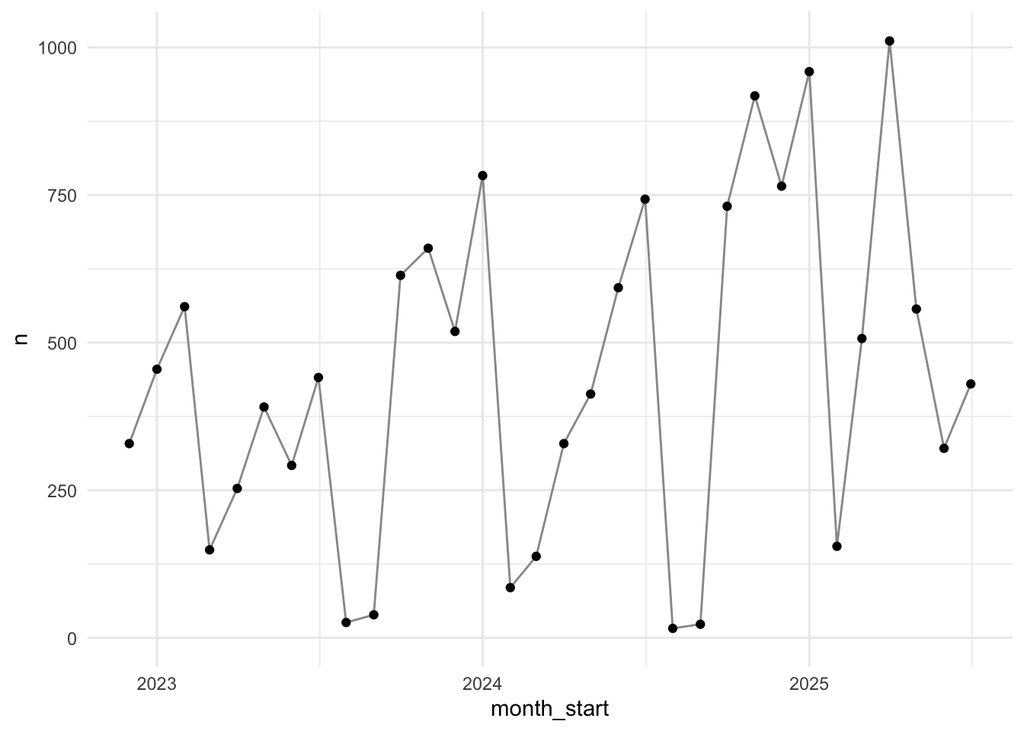

```r
time_visit_wday_summary |>
  group_by(year_num, month_start) |>
  summarise(n = n()) |>
  ggplot(aes(x = month_start, y = n)) +
  geom_line(group = 1, color = "grey60") +
  geom_point()
```

### 5.3.2 Pro Woche

```r
time_visit_wday_summary_week <-
time_visit_wday |>
  ungroup() |>
  mutate(week_start = floor_date(date_time, "week")) |>
  mutate(week_num = week(date_time),
         year_num = year(date_time))
```

```r
time_visit_wday_summary_week_summarized <-
time_visit_wday_summary_week   |>
  group_by(year_num, week_num) |>
  summarise(n = n())

time_visit_wday_summary_week_summarized
```

| year_num | week_num | n |
| --- | --- | --- |
| 2022 | 49 | 79 |
| 2022 | 50 | 117 |
| 2022 | 51 | 79 |
| 2022 | 52 | 51 |
| 2022 | 53 | 3 |
| 2023 | 1 | 63 |
| 2023 | 2 | 87 |
| 2023 | 3 | 123 |
| 2023 | 4 | 95 |
| 2023 | 5 | 442 |

[output cut: 128 more lines]

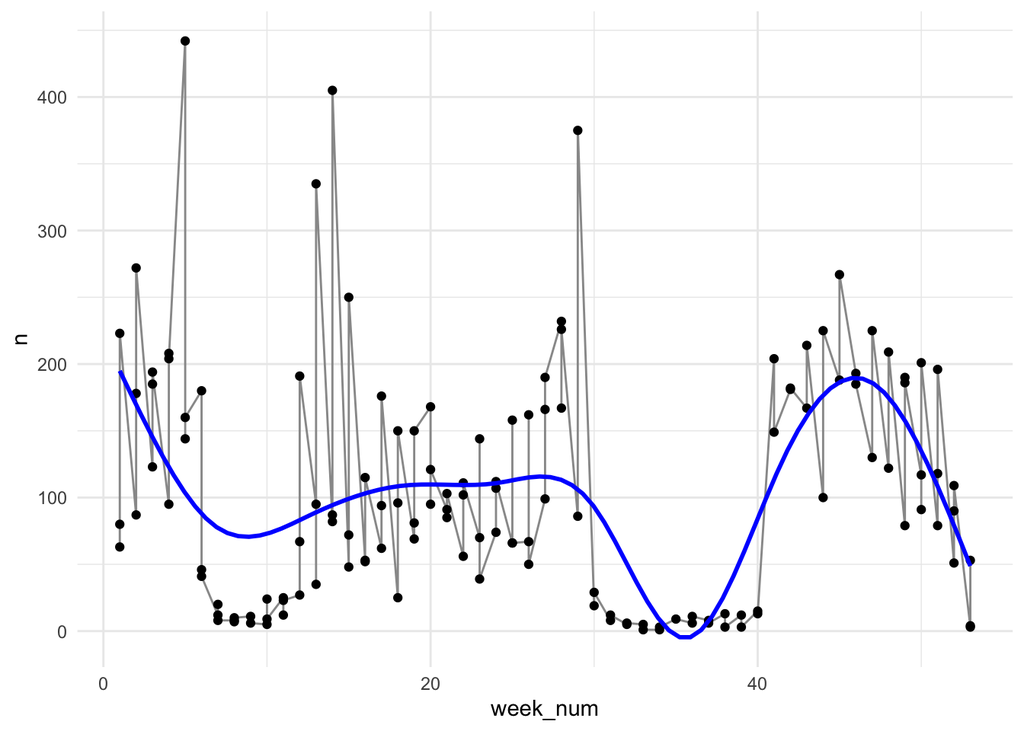

```r
time_visit_wday_summary_week_summarized |>
  ggplot(aes(x = week_num, y = n)) +
  geom_line(group = 1, color = "grey60") +
  geom_point() +
  geom_smooth(method = "gam", se = FALSE, color = "blue")
```

### 5.3.3 Akkumulierte Seitenaufrufe im Zeitverlauf

#### 5.3.3.1 Monat

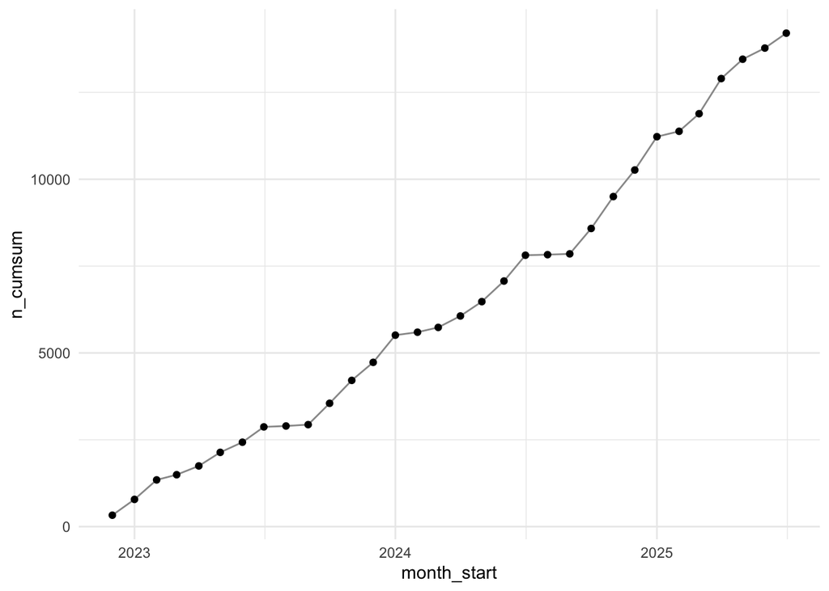

```r
time_visit_wday_summary |>
  group_by(year_num, month_start) |>
  summarise(n = n()) |>
  ungroup() |>
  mutate(n_cumsum = cumsum(n)) |>
  ggplot(aes(x = month_start, y = n_cumsum)) +
  geom_line(group = 1, color = "grey60") +
  geom_point() +
  theme_minimal()
```

#### 5.3.3.2 Woche

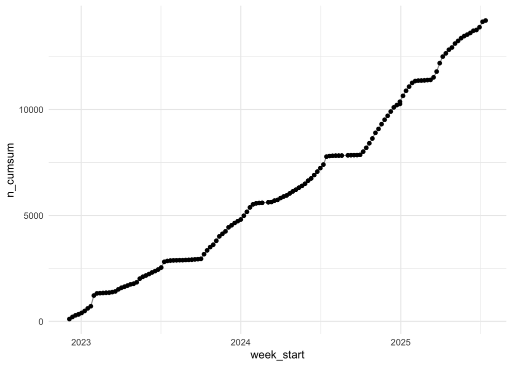

```r
time_visit_wday_summary_week |>
  group_by(year_num, week_start) |>
  summarise(n = n()) |>
  ungroup() |>
  mutate(n_cumsum = cumsum(n)) |>
  ggplot(aes(x = week_start, y = n_cumsum)) +
  geom_line(group = 1, color = "grey60") +
  geom_point() +
  theme_minimal()
```

## 5.4 Statistiken

Die folgenden Statistiken beruhen auf dem Datensatz `data_slim_filtered`:

```r
glimpse(data_slim_filtered)
```

```
Rows: 3,597,119
Columns: 4
$ nr      <int> 0, 0, 1, 1, 1, 1, 2, 2, 3, 3, 3, 3, 4, 4, 4, 4, 5, 5, 5, 5, 6,…
$ type    <fct> subtitle, timestamp, eventcategory, eventaction, timestamp, su…
$ value   <chr> "https://hans.th-nuernberg.de/", "2023-03-23 18:37:56", "click…
$ idvisit <int> 1, 1, 1, 1, 1, 1, 1, 1, 1, 1, 1, 1, 1, 1, 1, 1, 1, 1, 1, 1, 1,…
```

`nr` fasst die Nummer der Aktion innerhalb eines bestimmten Visits.

## 5.5 Mit allen Daten (den 499er-Daten)

```r
tbl_n_action <-
n_action |>
  describe_distribution(nr_max) |>
  gt() |>
  fmt_number(columns = where(is.numeric),
             decimals = 2)

tbl_n_action
```

| Variable | Mean | SD | IQR | Min | Max | Skewness | Kurtosis | n | n_Missing |
| --- | --- | --- | --- | --- | --- | --- | --- | --- | --- |
| nr_max | 79.75 | 122.53 | 88.00 | 1.00 | 499.00 | 2.24 | 4.41 | 14,207.00 | 0.00 |

```r
#gtsave(tbl_n_action, filename = "tbl_n_action.png")
```

[figure not shown]

`nr_max` gibt den Maximalwert von `nr` zurück, sagt also, wie viele Aktionen maximal während eines Vitis ausgeführt wurden.

Betrachtet man die Anzahl der Aktionen pro Visit näher, so fällt auf, dass der Maximalwert (499) sehr häufig vorkommt:

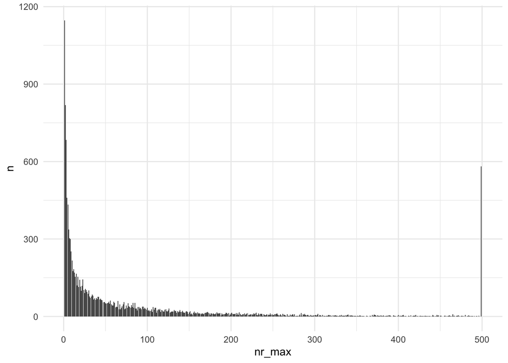

```r
n_action |>
  count(nr_max) |>
  ggplot(aes(x = nr_max, y = n)) +
  geom_col()
```

Hier noch in einer anderen Darstellung:

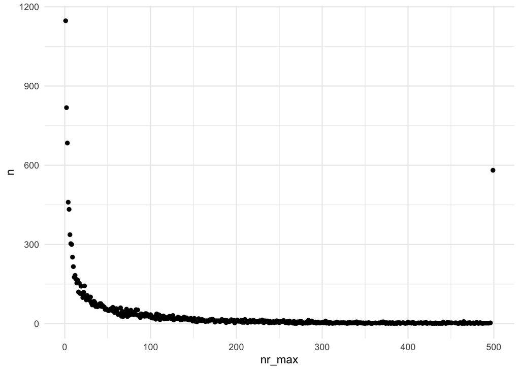

```r
n_action |>
  count(nr_max) |>
  ggplot(aes(x = nr_max, y = n)) +
  geom_point()
```

Der Maximalwert ist einfach auffällig häufig:

```r
n_action |>
  count(nr_max == 499) |>
  gt()
```

| nr_max == 499 | n |
| --- | --- |
| FALSE | 13626 |
| TRUE | 581 |

Es erscheint plausibel, dass der Maximalwert alle “gekappten” (*zensierten*, abgeschnittenen) Werte fasst, also viele Werte, die eigentlich größer wären (aber dann zensiert wurden).

## 5.6 Nur Visitors, für die weniger als 500 Aktionen protokolliert sind

```r
n_action_lt_500 <-
n_action |>
  filter(nr_max != 499)

n_action_lt_500 |>
  describe_distribution(nr_max) |>
  gt() |>
  fmt_number(columns = where(is.numeric),
             decimals = 2)
```

| Variable | Mean | SD | IQR | Min | Max | Skewness | Kurtosis | n | n_Missing |
| --- | --- | --- | --- | --- | --- | --- | --- | --- | --- |
| nr_max | 61.88 | 88.53 | 77.00 | 1.00 | 496.00 | 2.27 | 5.47 | 13,626.00 | 0.00 |

# 6 Lehrveranstaltungen

## 6.1 Anzahl an Lehrveranstaltungen

```r
course_and_uni_per_visit |>
count(university)
```

| university | n |
| --- | --- |
| evhn | 6 |
| hnu | 13 |
| hs-ansbach | 3 |
| hswt | 1109 |
| iqw | 1 |
| th-nuernberg | 4262 |
| th-owl | 1 |
| thi | 440 |
| NA | 8372 |

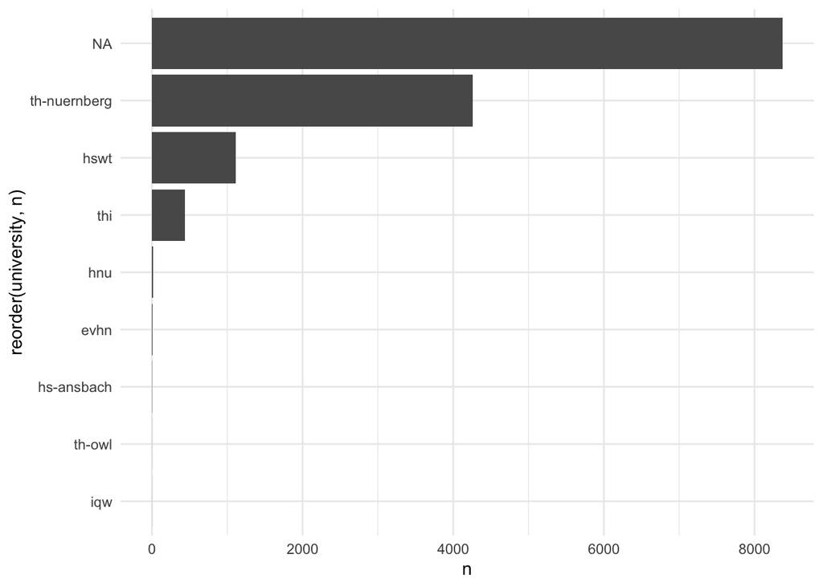

```r
course_and_uni_per_visit |>
count(university) |>
ggplot(aes(y = reorder(university, n), x = n)) +
geom_col() +
theme_minimal()
```

## 6.2 Visits nach Lehrveranstaltung und Jahr

```r
tar_load(time_spent_w_course_university)
```

```r
time_spent_w_course_university |>
count(year, course)
```

| year | course | n |
| --- | --- | --- |
| 2022 | NA | 329 |
| 2023 | NA | 4400 |
| 2024 | anis2 | 42 |
| 2024 | armeufa | 2 |
| 2024 | bare | 4 |
| 2024 | bio | 163 |
| 2024 | biotech | 127 |
| 2024 | biovete | 136 |
| 2024 | cta1 | 264 |
| 2024 | daba | 196 |

[output cut: 42 more lines]

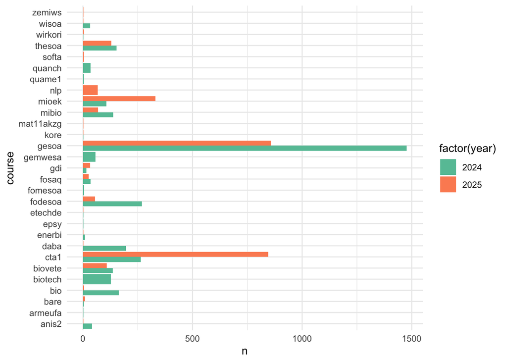

```r
time_spent_w_course_university |>
count(year, course) |>
drop_na() |>
ggplot(aes(x = n, y = course, fill = factor(year),)) +
geom_col(position = "dodge")
```

# 7 Aktionen pro Visit

## 7.1 Mit den 499er-Daten

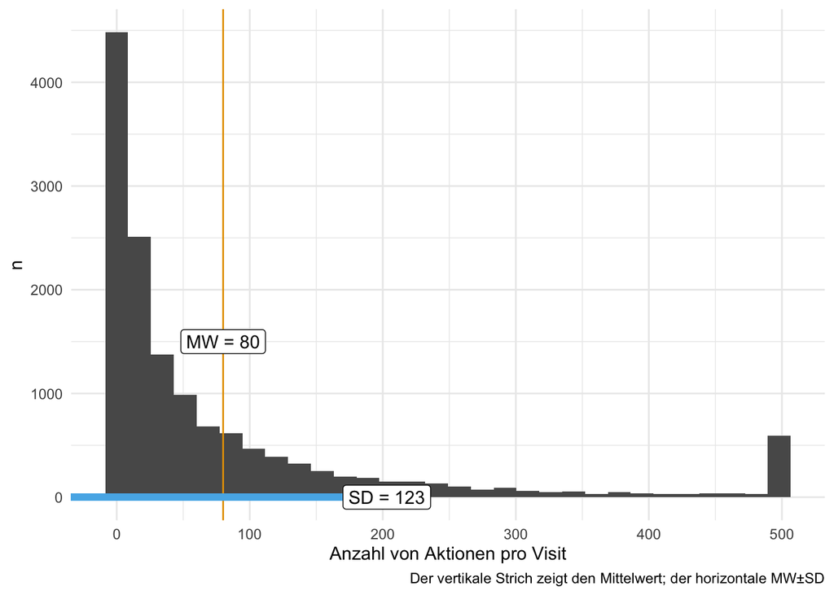

```r
n_action_avg = mean(n_action$nr_max) |> round(0)
n_action_sd = sd(n_action$nr_max) |> round(0)

n_action |>
  ggplot() +
  geom_histogram(aes(x = nr_max)) +
  labs(x = "Anzahl von Aktionen pro Visit",
       y = "n",
       caption = "Der vertikale Strich zeigt den Mittelwert; der horizontale MW±SD") +
  theme_minimal() +
  geom_vline(xintercept = n_action_avg,
             color = palette_okabe_ito()[1]) +
  geom_segment(x = n_action_avg - n_action_sd,
               y = 0,
               xend = n_action_avg + n_action_sd,
               yend = 0,
               color = palette_okabe_ito()[2],
               size = 2) +
  annotate("label", x = n_action_avg, y = 1500,
           label = paste0("MW = ", n_action_avg)) +
  annotate("label",
           x = n_action_avg + n_action_sd,
           y = 0,
           label = paste0("SD = ", n_action_sd))
```

```r
  #geom_label(aes(x = n_action_avg), y = 1, label = "Mean")
```

- Mittelwert der Aktionen pro Visit: 80.
- SD der Aktionen pro Visit: 123.

## 7.2 Ohne 499er-Daten

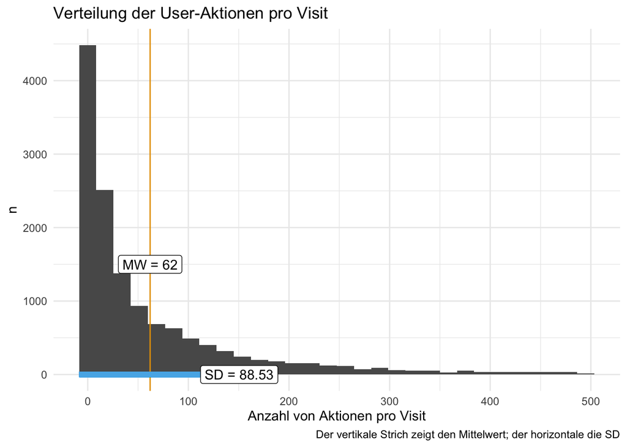

```r
n_action_avg2 = mean(n_action_lt_500$nr_max) |> round(0)
n_action_sd2 = sd(n_action_lt_500$nr_max) |> round(2)

n_action_lt_500 |>
  ggplot() +
  geom_histogram(aes(x = nr_max)) +
  labs(x = "Anzahl von Aktionen pro Visit",
       y = "n",
       title = "Verteilung der User-Aktionen pro Visit",
       caption = "Der vertikale Strich zeigt den Mittelwert; der horizontale die SD") +
  theme_minimal() +
  geom_vline(xintercept = n_action_avg2,
             color = palette_okabe_ito()[1]) +
  geom_segment(x = n_action_avg - n_action_sd2,
               y = 0,
               xend = n_action_avg2 + n_action_sd2,
               yend = 0,
               color = palette_okabe_ito()[2],
               size = 2) +
  annotate("label", x = n_action_avg2, y = 1500,
           label = paste0("MW = ", n_action_avg2)) +
  annotate("label",
           x = n_action_avg2 + n_action_sd2,
           y = 0,
           label = paste0("SD = ", n_action_sd2))
```

```r
  #geom_label(aes(x = n_action_avg), y = 1, label = "Mean")
```

- Mittelwert der Aktionen pro Visit: 62.
- SD der Aktionen pro Visit: 88.53.

## 7.3 Anzahl Aktionen im Zeitverlauf

### 7.3.1 Monat

```r
tar_load(n_action_w_date)
#n_action_w_date$month_date_str <- format(n_action_w_date$month_date, "%Y-%m")
```

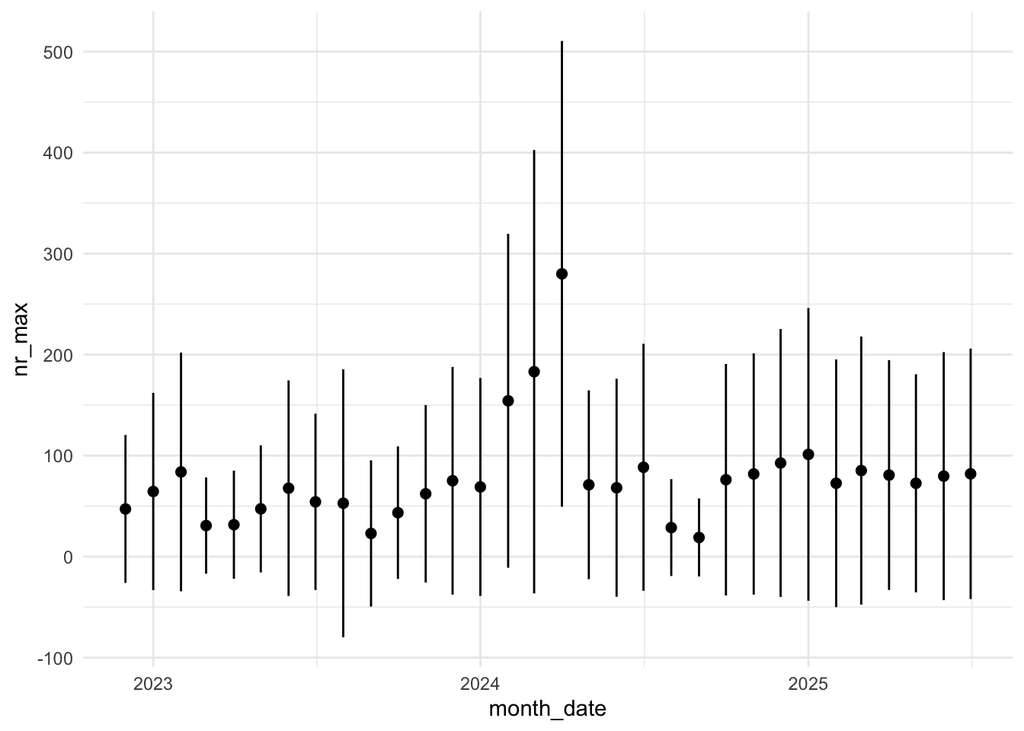

```r
n_action_w_date |>
  ggplot(aes(x = month_date, y = nr_max)) +
stat_summary(fun = mean, geom = "point", size = 2) +
stat_summary(fun.data = mean_sdl, fun.args = list(mult = 1), geom = "errorbar", width = 0.2)
```

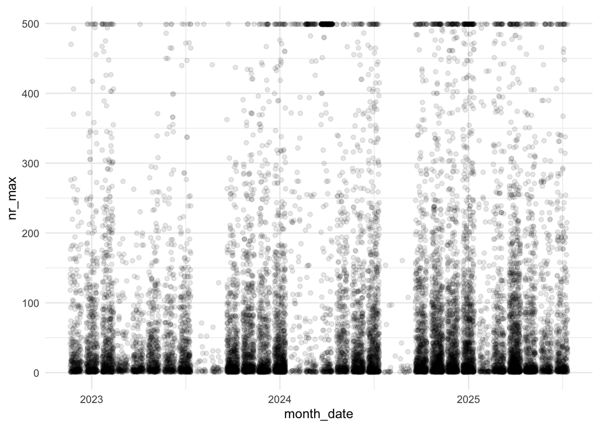

```r
n_action_w_date |>
  ggplot(aes(x = month_date, y = nr_max)) +
geom_jitter(alpha = .1)
```

### 7.3.2 Woche

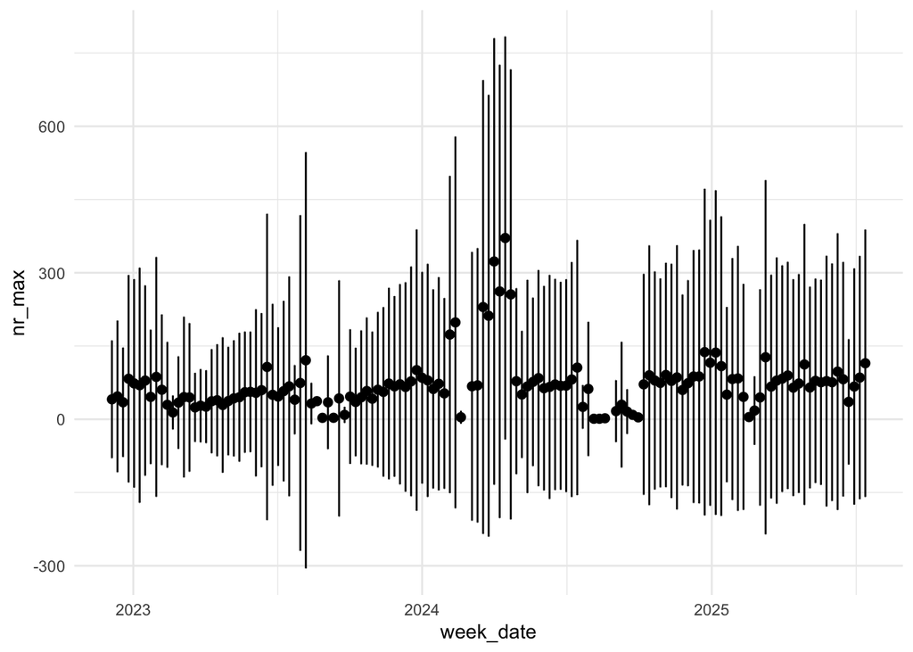

```r
n_action_w_date |>
  mutate(week_date = as.Date(week_date)) |>
  ggplot(aes(x = week_date, y = nr_max)) +
stat_summary(fun = mean, geom = "point", size = 2) +
stat_summary(fun.data = mean_sdl, geom = "errorbar", width = 0.2)
```

## 7.4 Gruppierung der Visits nach Anzahl der Aktionen

```r
n_action_lt_500 <-
n_action_lt_500 |>
 mutate(n_actions_type =
   case_when(nr_max < 30 ~ "glimpser",
             nr_max < 300 ~ "serious user",
             TRUE ~ "heavy user"))
```

```r
n_action_lt_500 |>
  count(n_actions_type) |>
  gt()
```

| n_actions_type | n |
| --- | --- |
| glimpser | 7388 |
| heavy user | 465 |
| serious user | 5773 |

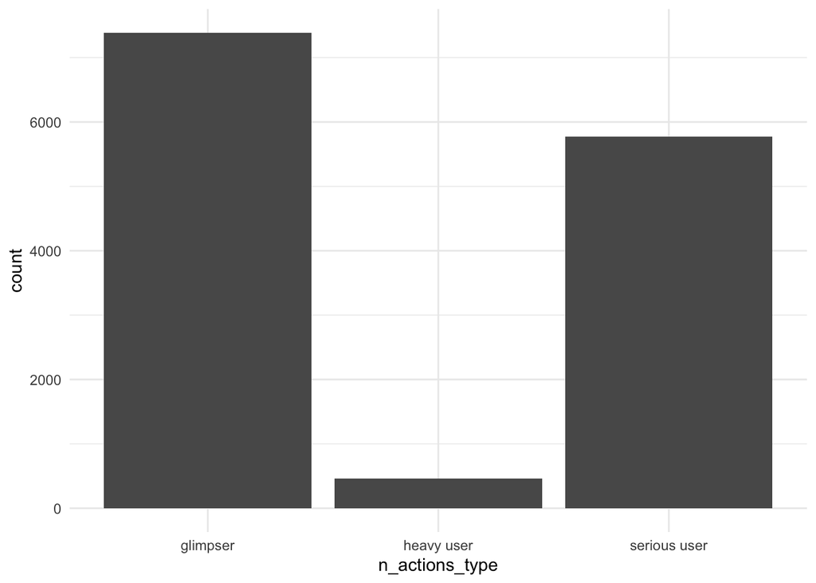

```r
ggplot(n_action_lt_500) +
aes(x = n_actions_type) +
geom_bar()
```

## 7.5 Gruppierung der Visits im Zeitverlauf

```r
tar_load(n_action_w_date)
```

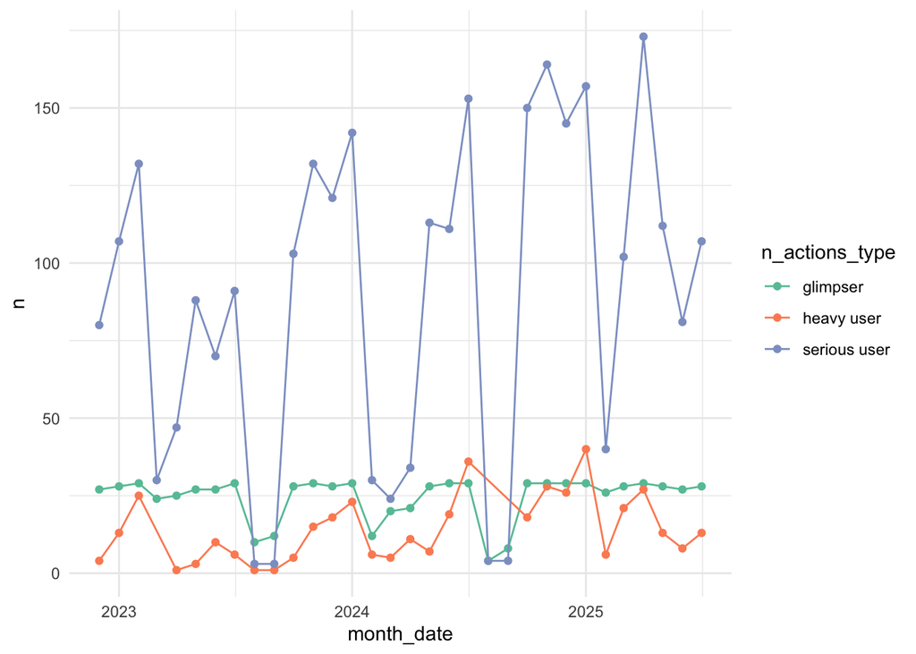

```r
n_action_w_date |>
group_by(month_date) |>
count(nr_max)  |>
mutate(n_actions_type =
case_when(nr_max < 30 ~ "glimpser",
nr_max < 300 ~ "serious user",
TRUE ~ "heavy user"))  |>
count(n_actions_type) |>
ggplot(aes(x = month_date, y = n,
color = n_actions_type, group = n_actions_type)) +
geom_point() +
geom_line()
```

# 8 Verweildauer pro Visit

## 8.1 Berechnungsgrundlage der Verweildauer

Die Verweildauer wurde berechnet als Differenz zwischen kleinstem und größtem Datumszeitwert (POSixct) eines Visits (also pro Wert der Variablen `idvisit`), vgl. [Funktion `diff_time](https://github.com/sebastiansauer/hans/blob/main/funs/diff_time.R). Diese Variable heißt`time_diff`im Objekt`time_spent`.

Dabei wird das Objekt `data_slim_filtered` herangezogen, vgl. [die Definition es Targets “time_spent” in der Targets-Pipeline](https://github.com/sebastiansauer/hans/blob/main/_targets.R#L205).

```r
#tar_load(data_slim_filtered)
#head(data_slim_filtered, 20)
```

## 8.2 Vorverarbeitung

Die Visit-Zeit wurde auf 600 Min. trunkiert/begrenzt.

```r
tar_load(time_spent)
tar_load(time_duration)
```

```r
time_spent |>
  head(30)
```

| idvisit | time_diff | time_min | time_max |
| --- | --- | --- | --- |
| 1 | 1493 secs | 2023-03-23 18:37:56 | 2023-03-23 19:02:49 |
| 2 | 2554 secs | 2023-03-23 17:18:10 | 2023-03-23 18:00:44 |
| 3 | 78 secs | 2023-03-23 17:17:36 | 2023-03-23 17:18:54 |
| 4 | 5478 secs | 2023-03-23 15:15:59 | 2023-03-23 16:47:17 |
| 5 | 1053 secs | 2023-03-23 14:20:12 | 2023-03-23 14:37:45 |
| 6 | 114 secs | 2023-03-23 14:29:42 | 2023-03-23 14:31:36 |
| 7 | 2084 secs | 2023-03-24 17:58:33 | 2023-03-24 18:33:17 |
| 8 | 1613 secs | 2023-03-24 16:06:55 | 2023-03-24 16:33:48 |
| 9 | 334 secs | 2023-03-24 16:21:10 | 2023-03-24 16:26:44 |
| 10 | 3011 secs | 2023-03-24 15:30:36 | 2023-03-24 16:20:47 |

[output cut: 20 more lines]

```r
time_spent <-
  time_spent |>
  # compute time (t) in minutes (min):
  mutate(t_minutes = as.numeric(time_diff, units = "mins")) |>
  filter(t_minutes < 600)
```

## 8.3 Verweildauer-Statistiken in Sekunden

Die Verweildauer ist im Folgenden dargestellt auf Grundlage oben dargestellter Berechnungsgrundlage (in Sekunden).

```r
time_spent |>
  summarise(
    mean_time_diff = round(mean(time_diff), 2),
    sd_time_diff = sd(time_diff),
    min_time_diff = min(time_diff),  # shortest duration
    max_time_diff = max(time_diff)  # longest
  )
```

| mean_time_diff | sd_time_diff | min_time_diff | max_time_diff |
| --- | --- | --- | --- |
| 1791.62 secs | 2395.619 | 0 secs | 28569 secs |

## 8.4 Verweildauer auf Basis der Variable `visitduration`

Alternativ zur Berechnung der Verweildauer steht eine Variable, `visitduration` zur Verfügung, die (offenbar) die Dauer des Visits misst bzw. messen soll.

```r
time_duration |>
  head(30)
```

| idvisit | visitduration_sec |
| --- | --- |
| 1 | 1494 |
| 2 | 2555 |
| 3 | 79 |
| 4 | 5479 |
| 5 | 1054 |
| 6 | 115 |
| 7 | 2085 |
| 8 | 1614 |
| 9 | 335 |
| 10 | 3012 |

[output cut: 20 more lines]

```r
time_duration |>
  summarise(duration_sec_avg = mean(visitduration_sec, na.rm = TRUE))  |>
  mutate(duration_min_avg = duration_sec_avg / 60)
```

| duration_sec_avg | duration_min_avg |
| --- | --- |
| 1884.463 | 31.40771 |

## 8.5 Verweildauer-Statistiken in Minuten

```r
time_spent |>
  mutate(time_diff_minutes = time_length(time_diff, unit = "minute")) |>
  summarise(
    mean_time_diff = round(mean(time_diff_minutes), 2),
    sd_time_diff = sd(time_diff_minutes),
    min_time_diff = min(time_diff_minutes),  # shortest duration
    max_time_diff = max(time_diff_minutes)  # longest
  )
```

| mean_time_diff | sd_time_diff | min_time_diff | max_time_diff |
| --- | --- | --- | --- |
| 29.86 | 39.92699 | 0 | 476.15 |

```r
small_padding_theme <- ggpubr::ttheme(
  tbody.style = tbody_style(size = 8), # Smaller font size can help
  colnames.style = colnames_style(size = 9, face = "bold"),
  padding = unit(c(2, 2), "mm") # Reduce horizontal and vertical padding
)
```

```r
ggpubr::ggtexttable(time_spent_summary,
                    rows = NULL,
                    theme = small_padding_theme)
```

[output not shown]

## 8.6 Visualisierung der Verweildauer

### 8.6.1 Binwidth=10 Minutes

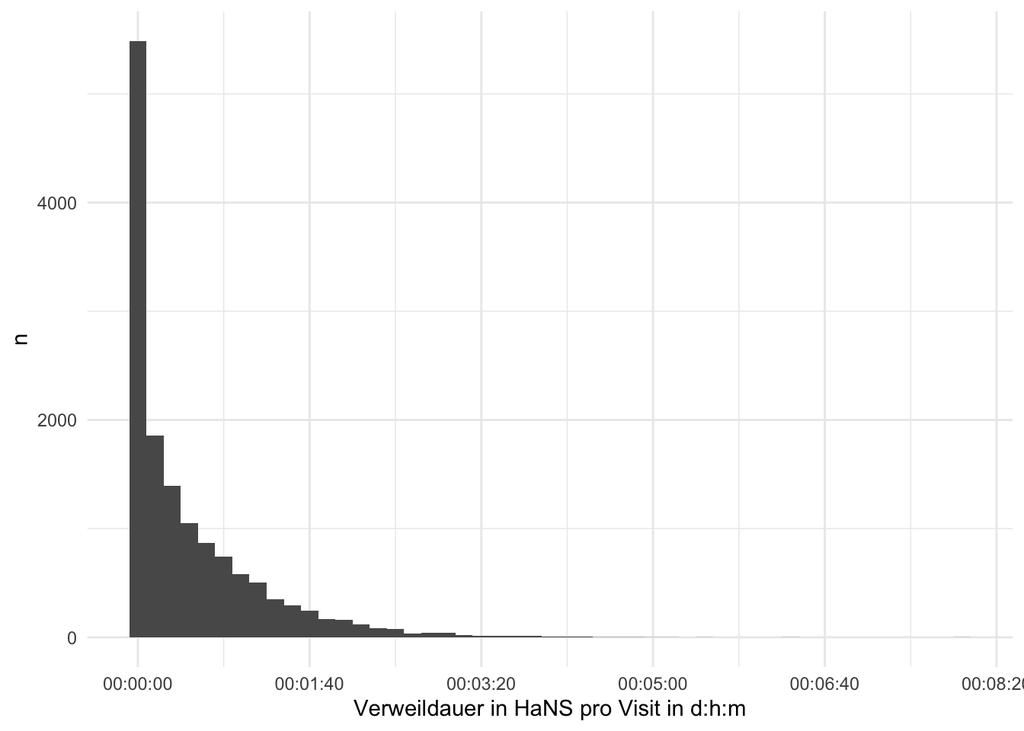

```r
time_spent |>
  mutate(time_diff_minutes = time_diff/60) |>
  ggplot(aes(x = time_diff_minutes)) +  # minutes
  geom_histogram(binwidth=10) +
  #scale_x_time() +
  theme_minimal() +
  labs(y = "n",
       x = "Verweildauer in HaNS pro Visit in d:h:m") +
  scale_x_time(breaks = pretty_breaks())
```

### 8.6.2 Bin width= 20 Minutes

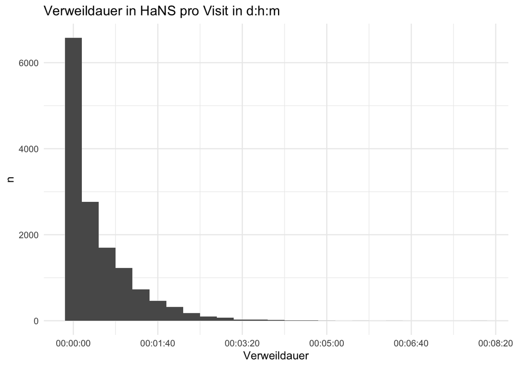

```r
time_spent |>
 mutate(time_diff_minutes = time_diff/60) |>
  ggplot(aes(x = time_diff_minutes)) +  # minutes
  geom_histogram(binwidth = 20) +
  theme_minimal() +
  labs(y = "n",
       x = "Verweildauer",
       title = "Verweildauer in HaNS pro Visit in d:h:m") +
  scale_x_time(breaks = pretty_breaks())
```

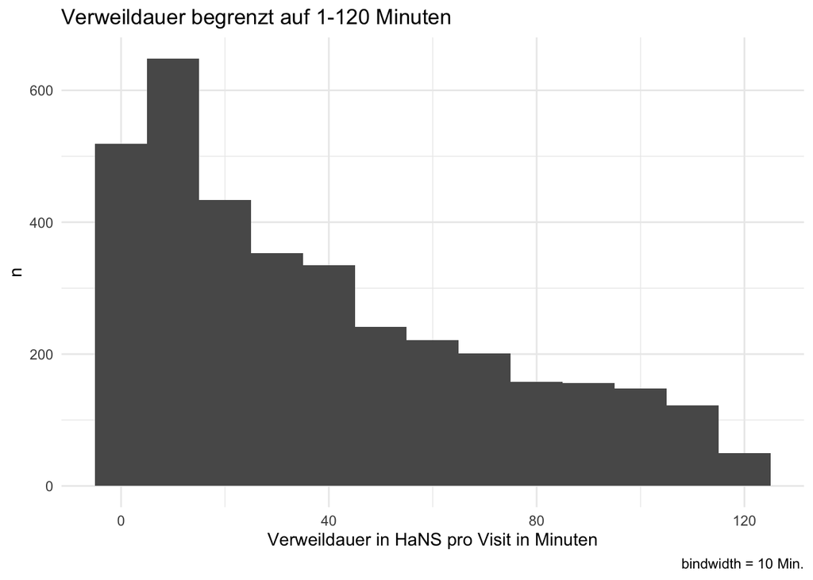

```r
time_spent2 <-
time_spent |>
  filter(time_diff > 1, time_diff < 120)

time_spent2 |>
  ggplot(aes(x = time_diff)) +
  geom_histogram(binwidth = 10) +
  theme_minimal() +
  labs(y = "n",
       x = "Verweildauer in HaNS pro Visit in Minuten",
       title = "Verweildauer begrenzt auf 1-120 Minuten",
       caption = "bindwidth = 10 Min.")
```

### 8.6.4 Veränderung der Verweildauer im Zeitverlauf

#### 8.6.4.1 Monat

```r
time_spent_by_month <-
  time_spent |>
  mutate(month_start = floor_date(time_min, "month")) |>
  mutate(month_name = month(month_start, label = TRUE, abbr = FALSE),
         month_num = month(month_start, label = FALSE),
         year = year(month_start)) |>
  group_by(month_num, year) |>
  summarise(time_spent_month_avg = mean(time_diff, na.rm = TRUE),
            time_spent_month_sd = sd(time_diff, na.rm = TRUE)) |>
  arrange(year, month_num)

time_spent_by_month
```

| month_num | year | time_spent_month_avg | time_spent_month_sd |
| --- | --- | --- | --- |
| 12 | 2022 | 1771.4043 secs | 2137.7115 |
| 1 | 2023 | 2063.3451 secs | 2721.8009 |
| 2 | 2023 | 2098.2888 secs | 2649.2932 |
| 3 | 2023 | 987.7315 secs | 1452.2422 |
| 4 | 2023 | 1172.5494 secs | 1975.9030 |
| 5 | 2023 | 2051.0895 secs | 2387.8641 |
| 6 | 2023 | 2349.4555 secs | 3092.3013 |
| 7 | 2023 | 1884.1769 secs | 2470.7454 |
| 8 | 2023 | 1219.2308 secs | 2742.9306 |
| 9 | 2023 | 315.1795 secs | 502.1187 |

[output cut: 22 more lines]

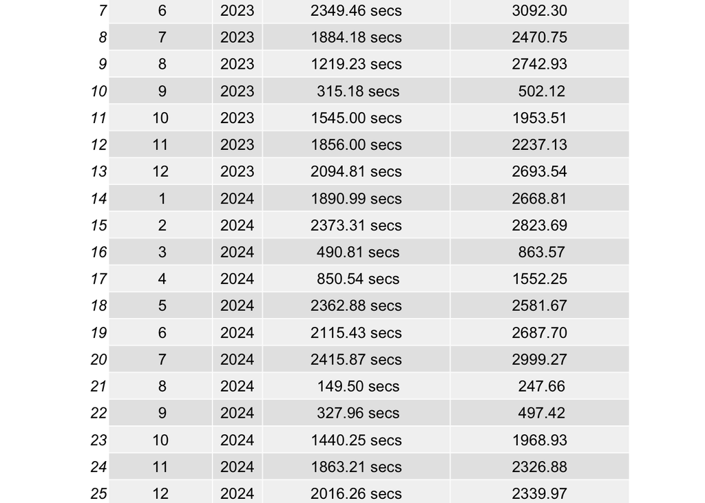

```r
time_spent_by_month |>
  mutate(time_spent_month_avg = round(time_spent_month_avg, 2),
         time_spent_month_sd = round(time_spent_month_sd, 2)) |>
  ggtexttable()
```

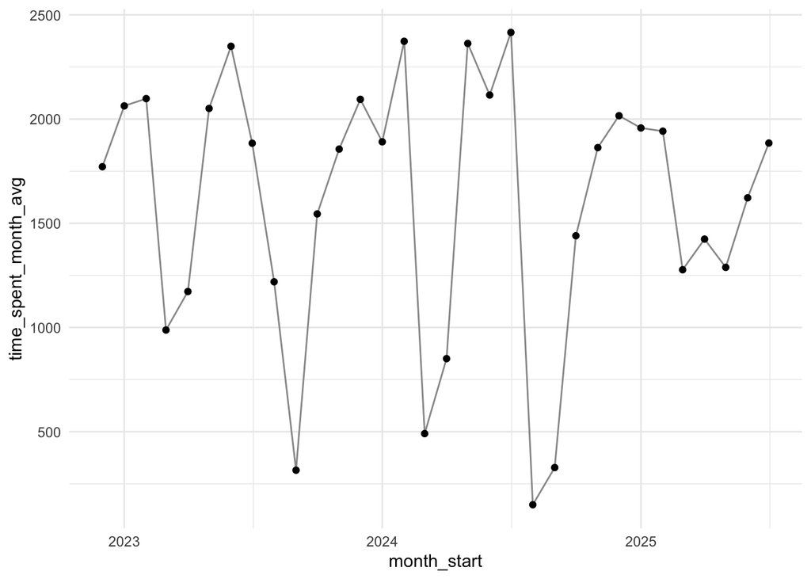

```r
time_spent_by_month_name <-
time_spent |>
  mutate(month_start = floor_date(time_min, "month")) |>
  mutate(month_name = month(month_start, label = TRUE, abbr = FALSE),
         month_num = month(month_start, label = FALSE),
         year = year(month_start)) |>
  group_by(month_start, year) |>
  summarise(time_spent_month_avg = mean(time_diff, na.rm = TRUE),
            time_spent_month_sd = sd(time_diff, na.rm = TRUE))

time_spent_by_month_name |>
ggplot(aes(x = month_start, y = time_spent_month_avg)) +
  geom_line(group = 1, color = "grey60") +
    geom_point()
```

#### 8.6.4.2 Woche

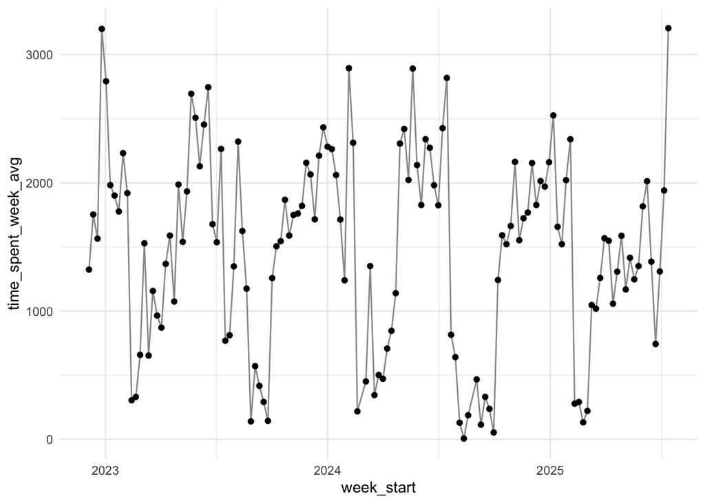

```r
time_spent_by_week_name <-
time_spent |>
  mutate(week_start = floor_date(time_min, "week")) |>
  mutate(week_num = week(week_start),
         year = year(week_start)) |>
  group_by(week_start, year) |>
  summarise(time_spent_week_avg = mean(time_diff, na.rm = TRUE),
            time_spent_week_sd = sd(time_diff, na.rm = TRUE))

time_spent_by_week_name |>
ggplot(aes(x = week_start, y = time_spent_week_avg)) +
  geom_line(group = 1, color = "grey60") +
    geom_point()
```

## 8.7 Zusammenhang von Lehrveranstaltung und Verweildauer

```r
tar_load(time_spent_w_course_university)
```

```r
time_spent_w_course_university_summary <-
time_spent_w_course_university |>
group_by(floor_date_month) |>
summarise(distinct_courses_n = n_distinct(course),
diff_time_mean = mean(time_diff, na.rm = TRUE),
n = n())

time_spent_w_course_university_summary
```

| floor_date_month | distinct_courses_n | diff_time_mean | n |
| --- | --- | --- | --- |
| 2022-12-01 | 1 | 1771.4043 secs | 329 |
| 2023-01-01 | 1 | 2063.3451 secs | 455 |
| 2023-02-01 | 1 | 2098.2888 secs | 561 |
| 2023-03-01 | 1 | 987.7315 secs | 149 |
| 2023-04-01 | 1 | 1172.5494 secs | 253 |
| 2023-05-01 | 1 | 2051.0895 secs | 391 |
| 2023-06-01 | 1 | 2349.4555 secs | 292 |
| 2023-07-01 | 1 | 1884.1769 secs | 441 |
| 2023-08-01 | 1 | 1219.2308 secs | 26 |
| 2023-09-01 | 1 | 315.1795 secs | 39 |

[output cut: 23 more lines]

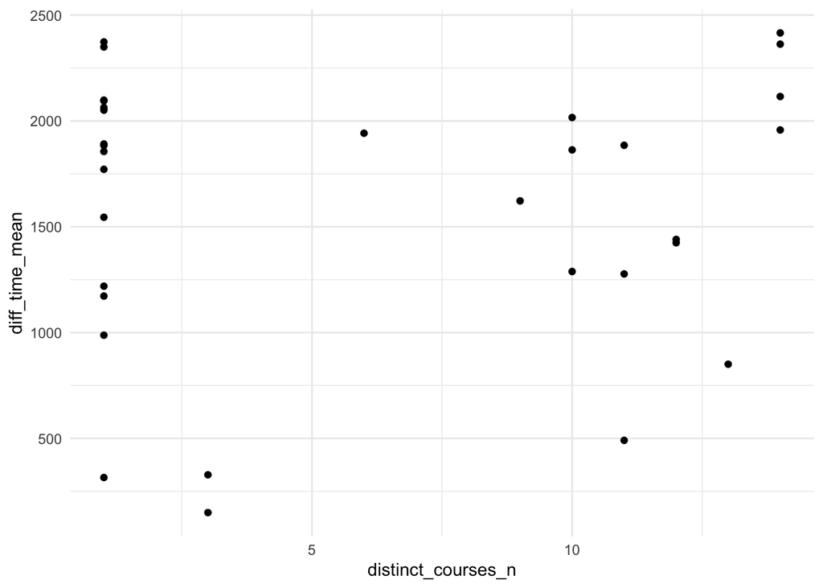

```r
time_spent_w_course_university_summary |>
ggplot(aes(x = distinct_courses_n, y = diff_time_mean)) +
geom_point()
```

## 8.8 Zusammenhang von Lehrveranstaltung und Anzahl Visits

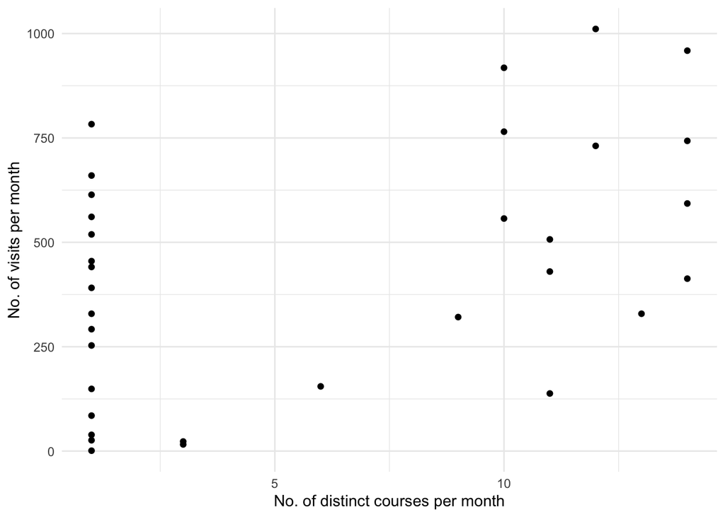

```r
time_spent_w_course_university_summary |>
ggplot(aes(x = distinct_courses_n, y = n)) +
geom_point() +
labs(y = "No. of visits per month",
x = "No. of distinct courses per month")
```

# 9 Was machen die User?

Was machen die Visitors eigentlich? Und wie oft?

## 9.1 Häufigkeiten

```r
tar_load(n_action_type)
```

Für das Objekt `n_action_type` wurde die Spalte `subtitle` in den Langformat-Daten ausgewertet, s. [Funktionsdefinition von `count_user_action_type`](https://github.com/sebastiansauer/hans/blob/main/funs/count_user_action.R).

```r
n_action_type |>
  head(30)
```

|  | nr | type | value | idvisit | category |
| --- | --- | --- | --- | --- | --- |
| 1 | 0 | subtitle | https://hans.th-nuernberg.de/ | 1 | visit_page |
| 2 | 0 | timestamp | 2023-03-23 18:37:56 | 1 | NA |
| 3 | 1 | timestamp | 2023-03-23 18:37:56 | 1 | NA |
| 4 | 1 | subtitle | Category: click_button, Action: Medien | 1 | Medien |
| 5 | 2 | subtitle | https://hans.th-nuernberg.de/channels | 1 | visit_page |
| 6 | 2 | timestamp | 2023-03-23 18:37:59 | 1 | NA |
| 7 | 3 | timestamp | 2023-03-23 18:37:59 | 1 | NA |
| 8 | 3 | subtitle | Category: click_button, Action: Kanäle | 1 | Kanäle |
| 9 | 4 | subtitle | BIO - Search Results Count: 26 | 1 | Search Results Count |
| 10 | 4 | timestamp | 2023-03-23 18:38:03 | 1 | NA |

[output cut: 20 more lines]

Achtung: Es kann sinnvoller sein, alternativ zu dieser Analyse die Analyse auf Basis von `eventcategory` heranzuziehen. Dort werden alle Arten von Events berücksichtigt. Hier, in der vorliegenden, nur ausgewählte Events.

### 9.1.1 Nach bestimmten Kategorien

```r
n_action_type_counted <-
n_action_type |>
  drop_na() |>
  count(category, sort = TRUE) |>
  mutate(prop = round(n/sum(n), 2))

n_action_type_counted |>
  gt()
```

| category | n | prop |
| --- | --- | --- |
| video | 845813 | 0.84 |
| click_slideChange | 61934 | 0.06 |
| visit_page | 55551 | 0.06 |
| Media item | 17485 | 0.02 |
| login | 6550 | 0.01 |
| in_media_search | 3422 | 0.00 |
| Search Results Count | 2856 | 0.00 |
| click_topic | 2799 | 0.00 |
| Medien | 1646 | 0.00 |
| logout | 1495 | 0.00 |
| Kanäle | 1395 | 0.00 |
| GESOA | 1358 | 0.00 |
| click_channelcard | 848 | 0.00 |
| Evaluation | 183 | 0.00 |
| Data protection | 39 | 0.00 |

### 9.1.2 Nach Kategorien im Zeitverlauf

```r
n_action_type_per_month <-
n_action_type |>
  select(nr, idvisit, category) |>
  ungroup() |>
  left_join(time_visit_wday |> ungroup()) |>
  select(-c(dow, hour, nr)) |>
  drop_na() |>
  mutate(month_start = floor_date(date_time, "month")) |>
  count(month_start, category)
```

```r
n_action_type_per_month
```

| month_start | category | n |
| --- | --- | --- |
| 2022-12-01 | GESOA | 8 |
| 2022-12-01 | Kanäle | 42 |
| 2022-12-01 | Medien | 53 |
| 2022-12-01 | Search Results Count | 109 |
| 2022-12-01 | click_channelcard | 24 |
| 2022-12-01 | click_slideChange | 1296 |
| 2022-12-01 | in_media_search | 67 |
| 2022-12-01 | logout | 15 |
| 2022-12-01 | video | 13073 |
| 2022-12-01 | visit_page | 816 |

[output cut: 386 more lines]

### 9.1.3 Nur die Top3-Kategorien

```r
tar_load(time_visit_wday)
```

```r
time_visit_wday |>
  head(30)
```

| idvisit | dow | hour | date_time |
| --- | --- | --- | --- |
| 1 | 4 | 18 | 2023-03-23 18:37:56 |
| 2 | 4 | 17 | 2023-03-23 17:18:10 |
| 3 | 4 | 17 | 2023-03-23 17:17:36 |
| 4 | 4 | 15 | 2023-03-23 15:15:59 |
| 5 | 4 | 14 | 2023-03-23 14:20:12 |
| 6 | 4 | 14 | 2023-03-23 14:29:42 |
| 7 | 5 | 17 | 2023-03-24 17:58:33 |
| 8 | 5 | 16 | 2023-03-24 16:06:55 |
| 9 | 5 | 16 | 2023-03-24 16:21:10 |
| 10 | 5 | 15 | 2023-03-24 15:30:36 |

[output cut: 20 more lines]

```r
n_action_type_per_month_top3 <-
n_action_type |>
  select(nr, idvisit, category) |>
  ungroup() |>
  filter(category %in% c("video", "click_slideChange", "visit_page")) |>
  left_join(time_visit_wday |> ungroup()) |>
  select(-c(dow, hour, nr)) |>
  drop_na() |>
  mutate(month_start = floor_date(date_time, "month")) |>
  count(month_start, category)
```

```r
n_action_type_per_month_top3
```

| month_start | category | n |
| --- | --- | --- |
| 2022-12-01 | click_slideChange | 1296 |
| 2022-12-01 | video | 13073 |
| 2022-12-01 | visit_page | 816 |
| 2023-01-01 | click_slideChange | 1688 |
| 2023-01-01 | video | 25163 |
| 2023-01-01 | visit_page | 1056 |
| 2023-02-01 | click_slideChange | 3453 |
| 2023-02-01 | video | 41503 |
| 2023-02-01 | visit_page | 1254 |
| 2023-03-01 | click_slideChange | 292 |

[output cut: 77 more lines]

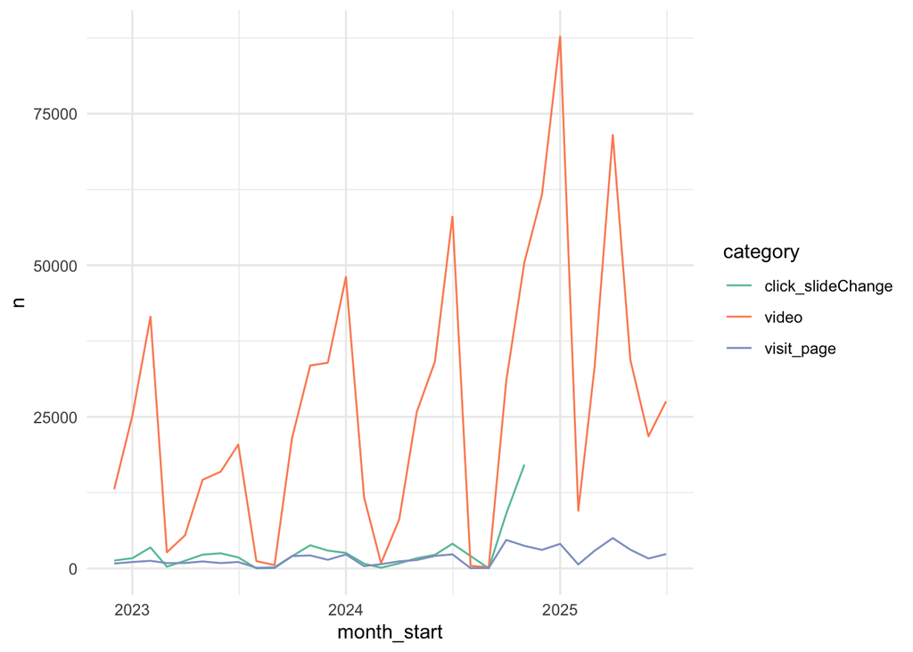

```r
n_action_type_per_month_top3 |>
  ggplot(aes(x = month_start, y = n, color = category, group = category)) +
  geom_line()
```

### 9.1.4 `eventcategory`

Für folgende Analyse wurde eine andere Variable als oben herangezogen, nämlich `eventcategory`. Dadurch resultieren etwas andere Ergebnisse.

```r
data_slim_filtered_count <-
data_slim_filtered |>
  filter(type == "eventcategory") |>
  count(value, sort = TRUE) |>
  mutate(prop = n / sum(n))

data_slim_filtered_count
```

| value | n | prop |
| --- | --- | --- |
| videoplayer_click | 646885 | 7.418610e-01 |
| clear_transcript_text_for_llm_context | 104108 | 1.193932e-01 |
| click_slideChange | 61934 | 7.102718e-02 |
| click_button | 20409 | 2.340546e-02 |
| click_transcript_word | 7882 | 9.039240e-03 |
| click_videocard | 7164 | 8.215822e-03 |
| verify_option_wrong | 4255 | 4.879721e-03 |
| login | 4147 | 4.755865e-03 |
| click_topic_position_using_image | 2229 | 2.556263e-03 |
| click_in_media_search_results | 1268 | 1.454168e-03 |

[output cut: 36 more lines]

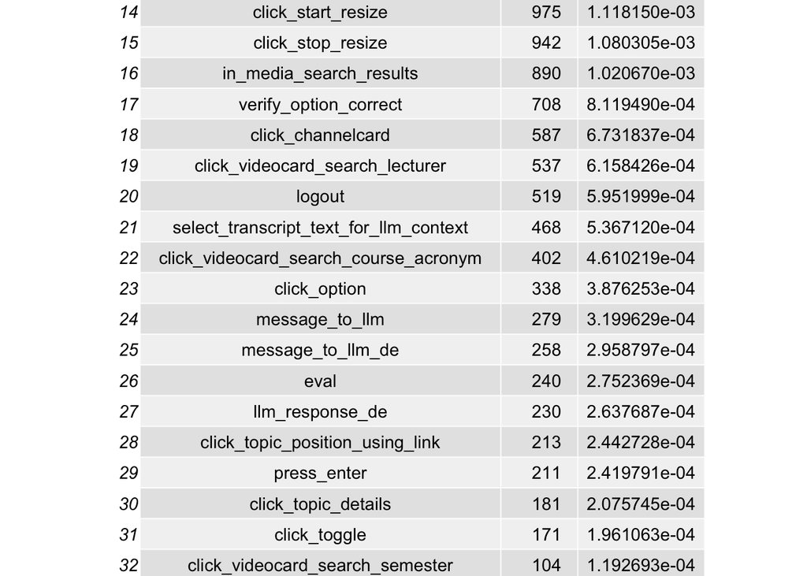

```r
data_slim_filtered_count |>
  ggtexttable()
```

Als Excel-Datei abspeichern:

```r
#data_slim_filtered_count |>
#  writexl::write_xlsx(path = "obj/data_slim_filtered_count.xlsx")
```

### 9.1.5 User-Typen nach Aktivitäten

Was ist die Hauptaktivität pro User? - Verteilung

```r
n_action_type_distro <-
n_action_type |>
group_by(idvisit) |>
summarise(category_max = max(category, na.rm = TRUE)) |>
count(category_max)

n_action_type_distro
```

| category_max | n |
| --- | --- |
| Evaluation | 3 |
| Kanäle | 1 |
| Search Results Count | 1 |
| click_slideChange | 27 |
| video | 2031 |
| visit_page | 12111 |
| NA | 33 |

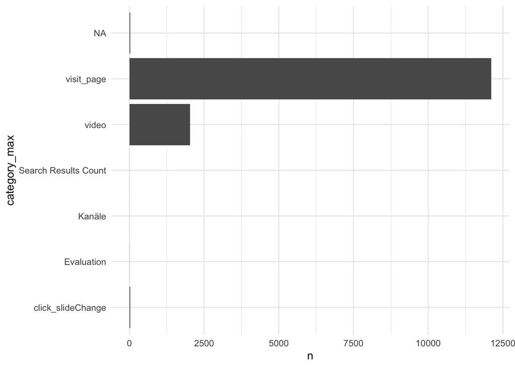

```r
n_action_type_distro |>
ggplot(aes(x = n, y = category_max)) +
geom_col()
```

## 9.2 Verteilung

```r
n_action_type_counted <-
n_action_type |>
  count(category, sort = TRUE)
```

### 9.2.1 Insgesamt - Rohwerte

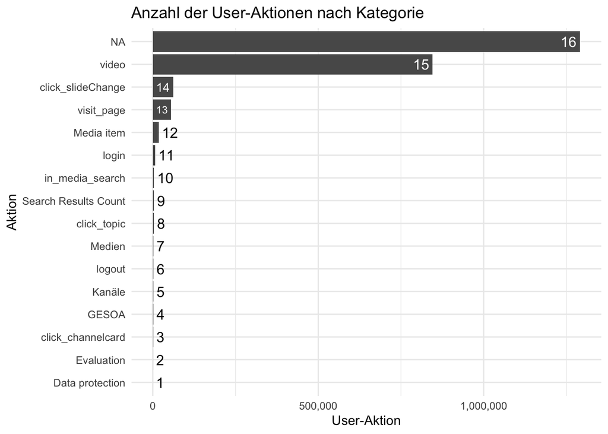

```r
n_action_type_counted |>
  ggplot(aes(y = reorder(category, n), x = n)) +
  geom_col() +
  geom_bar_text() +
  labs(
    x = "User-Aktion",
    y = "Aktion",
    title = "Anzahl der User-Aktionen nach Kategorie"
  ) +
  theme_minimal() +
  scale_x_continuous(labels = scales::comma)
```